# Sequence Clustering in Nestimate

# Purpose

Clustering separates sequences into groups with similar behavior. In Nestimate there are two families:

1. Distance-based clustering with `build_clusters()`.
2. Model-based clustering with `build_mmm()`.

The first compares observed sequences directly. The second fits a mixture of Markov chains and clusters sequences by transition dynamics.

# Build a Sequence Network First

We use a small sample of `human_long` to keep the rendered tutorial responsive. The clustering works on the stored sequence data inside the network object.

```r
data(human_long)

set.seed(2)
sessions <- sample(unique(human_long$session_id), 120)
human_sub <- human_long[human_long$session_id %in% sessions, ]

net <- build_network(
  human_sub,
  method = "relative",
  action = "cluster",
  actor = "session_id",
  time = "timestamp"
)

net
```

```
#> Transition Network (relative probabilities) [directed]
#>   Weights: [0.124, 0.605]  |  mean: 0.333
#>
#>   Weight matrix:
#>                 Directive Evaluative Metacognitive
#>   Directive         0.605      0.235         0.160
#>   Evaluative        0.471      0.405         0.124
#>   Metacognitive     0.438      0.327         0.235
#>
#>   Initial probabilities:
#>   Directive     0.905  ████████████████████████████████████████
#>   Evaluative    0.054  ██
#>   Metacognitive  0.041  ██
```

```r
dim(net$data)
```

```
#> [1] 147 160
```

```r
head(net$data[, 1:8])
```

|  | T1 | T2 | T3 | T4 | T5 | T6 | T7 | T8 |
| --- | --- | --- | --- | --- | --- | --- | --- | --- |
| 1 | Directive | Directive | Directive | Metacognitive | Evaluative | Directive | Evaluative | Evaluative |
| 2 | Directive | Directive | Directive | Metacognitive | Evaluative | Evaluative | Directive | Evaluative |
| 3 | Directive | Directive | Directive | Directive | Directive | Metacognitive | NA | NA |
| 4 | Directive | Directive | Directive | Evaluative | Directive | Metacognitive | NA | NA |
| 5 | Directive | Directive | Directive | Directive | Metacognitive | Directive | Directive | Evaluative |
| 6 | Directive | Directive | Directive | Directive | Metacognitive | Evaluative | Evaluative | Directive |

# Distance-Based Clustering

`build_clusters()` computes a distance matrix between sequences, then applies PAM or hierarchical clustering.

```r
cl <- build_clusters(
  net,
  k = 3,
  dissimilarity = "hamming",
  method = "pam",
  seed = 1
)

cl
```

```
#> Sequence Clustering [pam]
#>   Sequences: 147  |  Clusters: 3
#>   Dissimilarity: hamming
#>   Quality: silhouette = 0.487
#>
#>   Cluster  N            Mean within-dist  Medoid
#>   1        104 (70.7%)  10.539            107
#>   2        39 (26.5%)   34.656            122
#>   3        4 ( 2.7%)    96.333            18
```

```r
summary(cl)
```

```
#> Sequence Clustering Summary
#>   Method:        pam
#>   Dissimilarity: hamming
#>   Silhouette:    0.4875
#>
#> Per-cluster statistics:
#>  cluster size mean_within_dist
#>        1  104         10.53940
#>        2   39         34.65587
#>        3    4         96.33333
```

| cluster | size | mean_within_dist |
| --- | --- | --- |
| 1 | 104 | 10.53940 |
| 2 | 39 | 34.65587 |
| 3 | 4 | 96.33333 |

The main quantities are:

- `assignments`: one cluster label per sequence.
- `sizes`: number of sequences per cluster.
- `silhouette`: overall separation quality.
- `distance`: the pairwise dissimilarity matrix.
- `medoids`: representative sequences when `method = "pam"`.

```r
head(cl$assignments, 20)
```

```
#>  [1] 1 2 1 1 1 1 1 1 1 1 1 1 2 1 1 1 1 3 3 1
```

```r
cl$sizes
```

```
#>   1   2   3
#> 104  39   4
```

```r
cl$silhouette
```

```
#> [1] 0.4874613
```

# Inspect the Fit

The silhouette plot shows whether each sequence fits its assigned cluster.

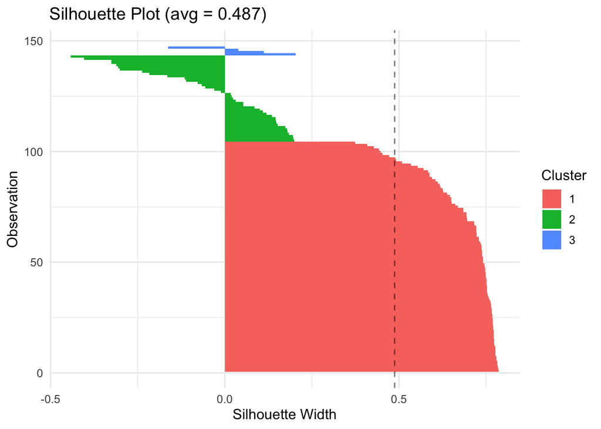

```r
plot(cl, type = "silhouette")
```

The MDS plot projects the distance matrix to two dimensions. It is a visual summary, not the clustering algorithm itself.

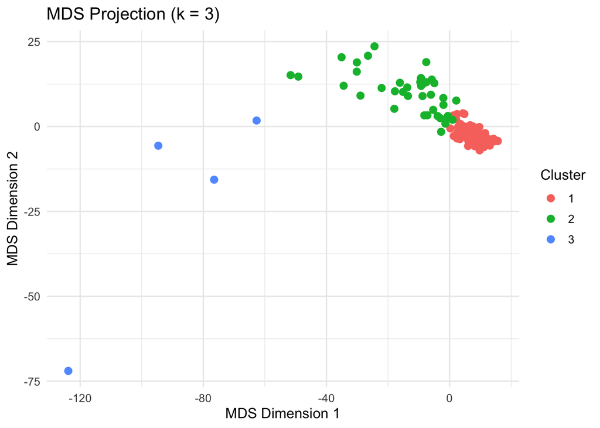

```r
plot(cl, type = "mds")
```

The heatmap shows the distance matrix ordered by cluster assignment.

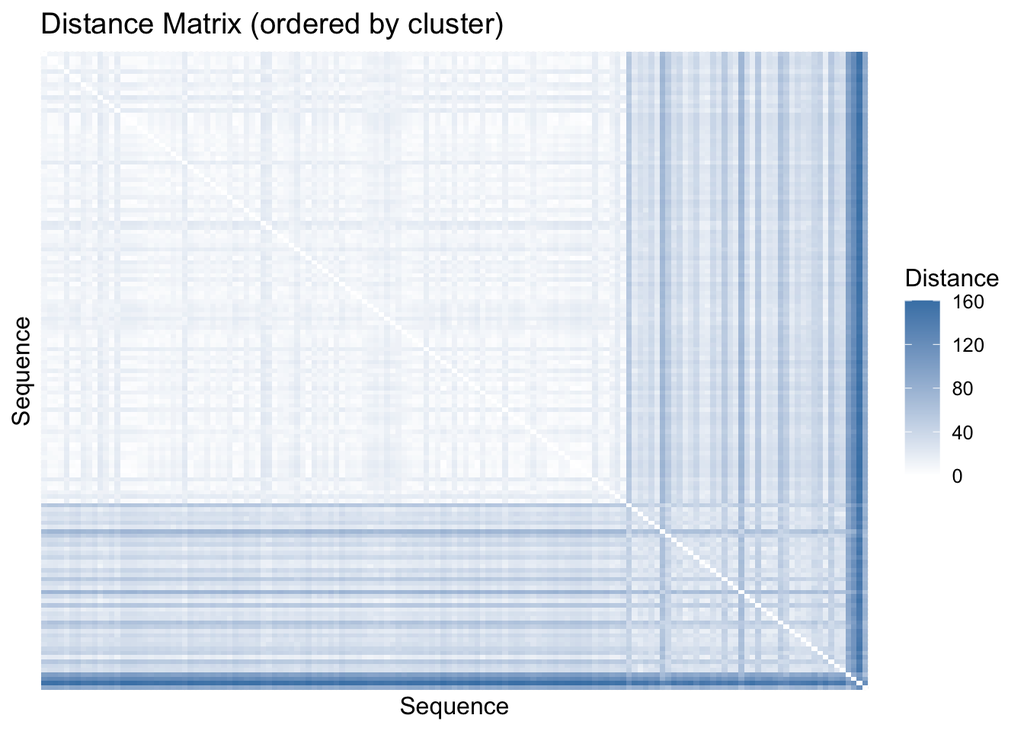

```r
plot(cl, type = "heatmap")
```

# Choose the Distance Metric

Different distances encode different assumptions.

```r
cl_hamming <- build_clusters(net, k = 3, dissimilarity = "hamming",
                             method = "ward.D2")
cl_lcs <- build_clusters(net, k = 3, dissimilarity = "lcs",
                         method = "ward.D2")
cl_lv <- build_clusters(net, k = 3, dissimilarity = "lv",
                        method = "ward.D2")

data.frame(
  distance = c("hamming", "lcs", "lv"),
  silhouette = c(cl_hamming$silhouette, cl_lcs$silhouette, cl_lv$silhouette),
  min_size = c(min(cl_hamming$sizes), min(cl_lcs$sizes), min(cl_lv$sizes)),
  max_size = c(max(cl_hamming$sizes), max(cl_lcs$sizes), max(cl_lv$sizes))
)
```

| distance | silhouette | min_size | max_size |
| --- | --- | --- | --- |
| hamming | 0.5457753 | 4 | 116 |
| lcs | 0.4629817 | 4 | 107 |
| lv | 0.3965039 | 4 | 77 |

Use Hamming when position-by-position alignment is meaningful. Use edit distances when insertions or shifts are meaningful. Use LCS when shared order matters more than exact timing.

Weighted Hamming gives more influence to earlier positions.

```r
cl_weighted <- build_clusters(
  net,
  k = 3,
  dissimilarity = "hamming",
  weighted = TRUE,
  lambda = 0.5,
  method = "ward.D2"
)

cl_weighted
```

```
#> Sequence Clustering [ward.D2]
#>   Sequences: 147  |  Clusters: 3
#>   Dissimilarity: hamming (weighted, lambda = 0.5)
#>   Quality: silhouette = 0.552
#>
#>   Cluster  N            Mean within-dist
#>   1        119 (81.0%)  0.425
#>   2        14 ( 9.5%)   1.095
#>   3        14 ( 9.5%)   1.650
```

# Sweep Choices With `cluster_choice()`

Manual one-off comparisons are fine for learning. For real work, sweep the candidate space explicitly.

```r
choice <- cluster_choice(
  net,
  k = 2:5,
  dissimilarity = c("hamming", "lcs", "lv"),
  method = c("pam", "ward.D2"),
  seed = 1
)

choice
```

| k | dissimilarity | method | silhouette | mean_within_dist | min_size | max_size | size_ratio |
| --- | --- | --- | --- | --- | --- | --- | --- |
| 2 | hamming | pam | 0.4878319 | 21.20928 | 43 | 104 | 2.418605 |
| 3 | hamming | pam | 0.4874613 | 19.27217 | 4 | 104 | 26.000000 |
| 4 | hamming | pam | 0.3053724 | 17.43428 | 4 | 69 | 17.250000 |
| 5 | hamming | pam | 0.3030353 | 16.03047 | 1 | 69 | 69.000000 |
| 2 | lcs | pam | 0.4458042 | 18.82076 | 49 | 98 | 2.000000 |
| 3 | lcs | pam | 0.3424786 | 16.74920 | 15 | 87 | 5.800000 |
| 4 | lcs | pam | 0.1631278 | 15.87808 | 15 | 50 | 3.333333 |
| 5 | lcs | pam | 0.1658490 | 14.84915 | 1 | 50 | 50.000000 |
| 2 | lv | pam | 0.5738323 | 16.40129 | 36 | 111 | 3.083333 |
| 3 | lv | pam | 0.3603836 | 13.97757 | 20 | 71 | 3.550000 |

[output cut: 14 more lines]

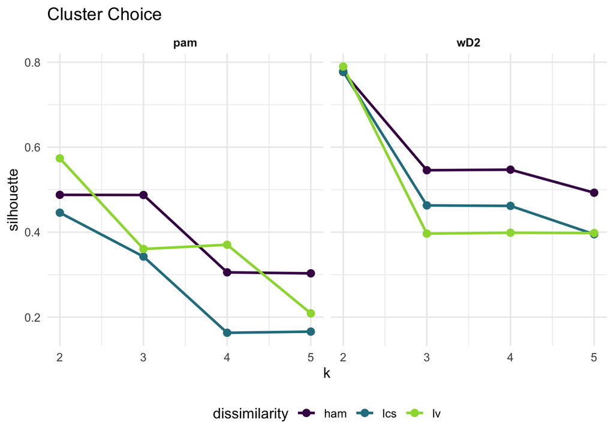

```r
plot(choice, type = "facet", abbrev = TRUE)
```

Silhouette is useful, but do not choose from it alone. A high silhouette with a very small cluster may be a poor substantive solution.

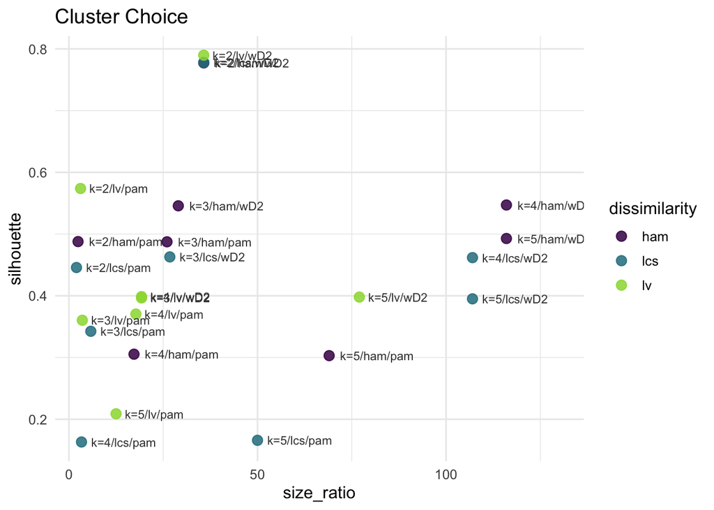

```r
plot(choice, type = "tradeoff", abbrev = TRUE)
```

# Diagnostics

`cluster_diagnostics()` gives a common diagnostic surface for distance clustering and MMM.

```r
diag <- cluster_diagnostics(cl_hamming)
diag
```

```
#> Cluster Diagnostics (distance) [ward.D2 / hamming]
#>   Sequences: 147  |  Clusters: 3
#>   Quality: silhouette = 0.546
#>
#>   Cluster  N            Mean within-dist  Silhouette
#>   1        116 (78.9%)  12.694            0.680
#>   2        27 (18.4%)   37.573            0.045
#>   3        4 ( 2.7%)    96.333            0.029
```

```r
as.data.frame(diag)
```

| cluster | size | pct | mean_within_dist | sil_mean |
| --- | --- | --- | --- | --- |
| 1 | 116 | 78.911565 | 12.69370 | 0.68006460 |
| 2 | 27 | 18.367347 | 37.57265 | 0.04544515 |
| 3 | 4 | 2.721088 | 96.33333 | 0.02861257 |

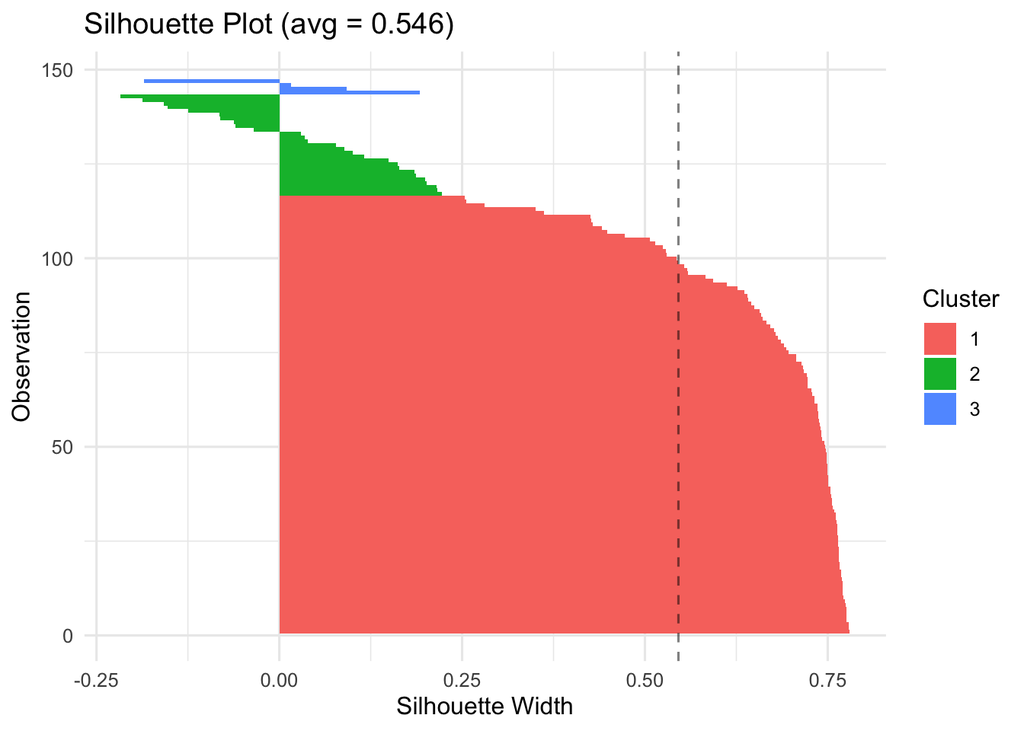

```r
plot(diag, type = "silhouette")
```

# Build Per-Cluster Networks

`build_clusters()` returns clustering results, not per-cluster networks. Pass the clustering object to `build_network()` to estimate one network per cluster.

```r
cluster_nets <- build_network(cl_hamming, method = "relative")
cluster_nets
```

```
#> Group Networks (3 clusters via ward.D2 / hamming)
#>
#>   Group      Nodes  Edges  Weights         N
#>   Cluster 1  3      9      [0.151, 0.667]  116 (78.9%)
#>   Cluster 2  3      9      [0.142, 0.580]  27 (18.4%)
#>   Cluster 3  3      9      [0.057, 0.521]  4 ( 2.7%)
```

```r
names(cluster_nets)
```

```
#> [1] "Cluster 1" "Cluster 2" "Cluster 3"
```

Each member is a normal `netobject`.

```r
lapply(cluster_nets, function(x) round(x$weights, 2))
```

```
#> $`Cluster 1`
#>               Directive Evaluative Metacognitive
#> Directive          0.67       0.17          0.16
#> Evaluative         0.50       0.35          0.15
#> Metacognitive      0.46       0.33          0.22
#>
#> $`Cluster 2`
#>               Directive Evaluative Metacognitive
#> Directive          0.58       0.26          0.16
#> Evaluative         0.47       0.39          0.14
#> Metacognitive      0.45       0.28          0.27
#>
#> $`Cluster 3`
#>               Directive Evaluative Metacognitive
#> Directive          0.43       0.44          0.14
#> Evaluative         0.44       0.50          0.06
#> Metacognitive      0.31       0.52          0.17
```

The one-call wrapper is `cluster_network()`.

```r
cluster_nets2 <- cluster_network(
  net,
  k = 3,
  cluster_by = "ward.D2",
  dissimilarity = "hamming"
)

cluster_nets2
```

```
#> Group Networks (3 clusters via ward.D2 / hamming)
#>
#>   Group      Nodes  Edges  Weights         N
#>   Cluster 1  3      9      [0.151, 0.667]  116 (78.9%)
#>   Cluster 2  3      9      [0.142, 0.580]  27 (18.4%)
#>   Cluster 3  3      9      [0.057, 0.521]  4 ( 2.7%)
```

# Model-Based Clustering With MMM

Mixed Markov Models cluster sequences by transition dynamics. Each component has its own transition matrix.

```r
set.seed(1)
mmm <- build_mmm(net, k = 2, n_starts = 5, max_iter = 80, seed = 1)
mmm
```

```
#> Mixed Markov Model
#>   Sequences: 147  |  Clusters: 2  |  States: 3
#>   ICs: LL = -3011.030  |  BIC = 6106.898  |  AIC = 6056.061  |  ICL = 6152.092
#>   Quality: AvePP = 0.870  |  Entropy = 0.439  |  Class.Err = 0.0%
#>
#>   Cluster  N            Mix%   AvePP
#>   1        121 (82.3%)  74.1%  0.871
#>   2        26 (17.7%)   25.9%  0.865
```

```r
summary(mmm)
```

```
#> Mixed Markov Model
#>   Sequences: 147  |  Clusters: 2  |  States: 3
#>   ICs: LL = -3011.030  |  BIC = 6106.898  |  AIC = 6056.061  |  ICL = 6152.092
#>   Quality: AvePP = 0.870  |  Entropy = 0.439  |  Class.Err = 0.0%
#>
#>   Cluster  N            Mix%   AvePP
#>   1        121 (82.3%)  74.1%  0.871
#>   2        26 (17.7%)   25.9%  0.865
#>
#> --- Cluster 1 (74.1%, n=121) ---
#>               Directive Evaluative Metacognitive
#> Directive         0.662      0.158         0.181
#> Evaluative        0.505      0.306         0.189
#> Metacognitive     0.479      0.263         0.257
#>
#> --- Cluster 2 (25.9%, n=26) ---
#>               Directive Evaluative Metacognitive
#> Directive         0.506      0.371         0.123
#> Evaluative        0.449      0.469         0.082
#> Metacognitive     0.342      0.476         0.182
```

| component | prior | n_assigned | mean_posterior | avepp |
| --- | --- | --- | --- | --- |
| 1 | 0.7412483 | 121 | 0.8713998 | 0.8713998 |
| 2 | 0.2587517 | 26 | 0.8645289 | 0.8645289 |

Posterior probabilities show assignment certainty.

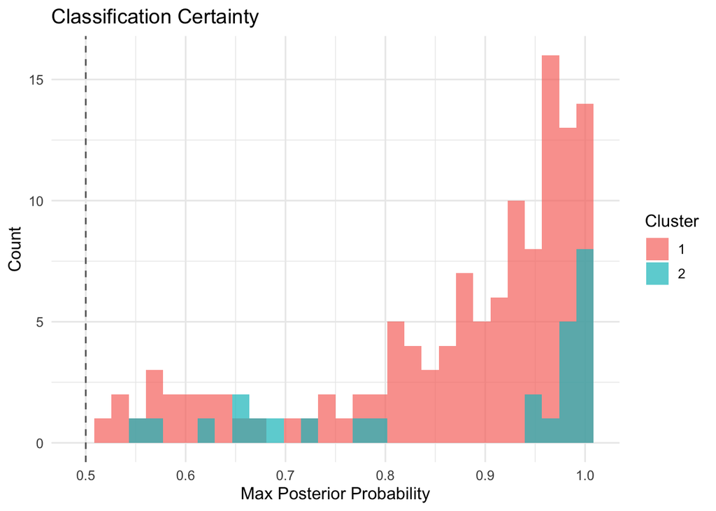

```r
plot(mmm, type = "posterior")
```

Compare component counts with `compare_mmm()`.

```r
cmp <- compare_mmm(net, k = 2:4, n_starts = 3, max_iter = 60, seed = 1)
cmp
```

| k | log_likelihood | AIC | BIC | ICL | AvePP | Entropy | converged |
| --- | --- | --- | --- | --- | --- | --- | --- |
| 2 | -3011.030 | 6056.061 | 6106.898 | 6152.092 | 0.8701845 | 0.4393172 | TRUE |
| 3 | -2996.435 | 6044.870 | 6122.622 | 6218.430 | 0.7405338 | 0.4937137 | FALSE |
| 4 | -2990.102 | 6050.205 | 6154.870 | 6263.949 | 0.7113245 | 0.4684140 | FALSE |

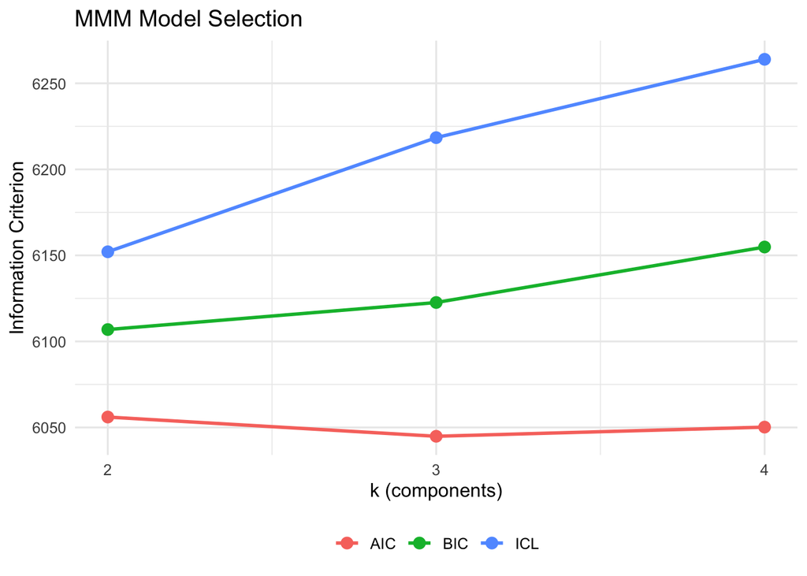

```r
plot(cmp)
```

Build per-component networks with `cluster_mmm()`.

```r
mmm_nets <- cluster_mmm(net, k = 2, n_starts = 5, max_iter = 80, seed = 1)
mmm_nets
```

```
#> Group Networks (2 clusters from MMM)
#>
#>   Group      Nodes  Edges  Weights         N
#>   Cluster 1  3      9      [0.158, 0.662]  121 (82.3%)
#>   Cluster 2  3      9      [0.082, 0.506]  26 (17.7%)
```

```r
cluster_diagnostics(mmm_nets)
```

```
#> Cluster Diagnostics (mmm) [k = 2]
#>   Sequences: 147  |  Clusters: 2  |  States: 3
#>   Quality: AvePP = 0.870  |  Entropy = 0.439  |  Class.Err = 0.0%
#>   ICs: LL = -3011.030  |  BIC = 6106.898  |  AIC = 6056.061  |  ICL = 6152.092
#>
#>   Cluster  N            Mix%   AvePP  Class.Err%
#>   1        121 (82.3%)  74.1%  0.871   0.0%
#>   2        26 (17.7%)   25.9%  0.865   0.0%
```

# Covariates

Distance clustering treats covariates as post-hoc descriptors. They do not change the cluster assignments.

```r
cl_cov <- build_clusters(
  net,
  k = 3,
  method = "ward.D2",
  covariates = c("project")
)

summary(cl_cov)
```

```
#> Sequence Clustering Summary
#>   Method:        ward.D2
#>   Dissimilarity: hamming
#>   Silhouette:    0.5458
#>
#> Per-cluster statistics:
#>  cluster size mean_within_dist
#>        1  116         12.69370
#>        2   27         37.57265
#>        3    4         96.33333
#>
#> Post-hoc Covariate Analysis (does not influence cluster membership)
#>
#> Cluster Profiles (categorical):
#>  Cluster N   project=Project_12 N(%) project=Project_13 N(%)
#>  1       116 1 (1%)                  8 (7%)
#>  2        27 0 (0%)                  2 (7%)
#>  3         4 0 (0%)                  0 (0%)
#>  project=Project_14 N(%) project=Project_17 N(%) project=Project_19 N(%)
#>  1 (1%)                  11 (10%)                3 (3%)
#>  0 (0%)                  3 (11%)                 0 (0%)
#>  0 (0%)                  2 (50%)                 0 (0%)
#>  project=Project_20 N(%) project=Project_21 N(%) project=Project_22 N(%)
#>  2 (2%)                  1 (1%)                  1 (1%)
#>  0 (0%)                  1 (4%)                  1 (4%)
#>  0 (0%)                  0 (0%)                  0 (0%)
#>  project=Project_24 N(%) project=Project_25 N(%) project=Project_27 N(%)
#>  4 (3%)                  13 (11%)                2 (2%)
#>  4 (15%)                 0 (0%)                  1 (4%)
#>  0 (0%)                  0 (0%)                  0 (0%)
#>  project=Project_29 N(%) project=Project_3 N(%) project=Project_30 N(%)
#>  1 (1%)                  1 (1%)                 1 (1%)
#>  1 (4%)                  1 (4%)                 0 (0%)
#>  0 (0%)                  0 (0%)                 0 (0%)
#>  project=Project_32 N(%) project=Project_33 N(%) project=Project_34 N(%)
#>  1 (1%)                  10 (9%)                 1 (1%)
#>  0 (0%)                  3 (11%)                 0 (0%)
#>  0 (0%)                  0 (0%)                  0 (0%)
#>  project=Project_5 N(%) project=Project_7 N(%) project=Project_8 N(%)
#>  15 (13%)               29 (25%)               1 (1%)
```

[output cut: 26 more lines]

[output not shown]

|  | cluster | size | mean_within_dist |
| --- | --- | --- | --- |
| 1 | 1 | 116 | 12.69370 |
| 2 | 2 | 27 | 37.57265 |
| 3 | 3 | 4 | 96.33333 |

MMM covariates are different. They are part of the model and affect the mixing proportions.

```r
mmm_cov <- build_mmm(
  net,
  k = 2,
  n_starts = 3,
  max_iter = 60,
  seed = 1,
  covariates = c("project")
)

mmm_cov
```

```
#> Mixed Markov Model
#>   Sequences: 147  |  Clusters: 2  |  States: 3
#>   ICs: LL = -2997.180  |  BIC = 6084.187  |  AIC = 6030.359  |  ICL = 6125.258
#>   Quality: AvePP = 0.882  |  Entropy = 0.381  |  Class.Err = 0.0%
#>
#>   Cluster  N           Mix%   AvePP
#>   1        52 (35.4%)  38.6%  0.880
#>   2        95 (64.6%)  61.4%  0.884
#>
#>   Covariates: projectProject_13, projectProject_14, projectProject_16, projectProject_17, projectProject_19, projectProject_20, projectProject_21, projectProject_22, projectProject_24, projectProject_25, projectProject_26, projectProject_27, projectProject_29, projectProject_3, projectProject_30,…
```

# A Sensible Workflow

1. Build a transition network to prepare and inspect the sequence data.
2. Try a small set of defensible distances and clustering methods.
3. Use `cluster_choice()` to compare the candidates.
4. Inspect the chosen solution with `cluster_diagnostics()`.
5. Build per-cluster networks with `build_network(clustering)` or `cluster_network()`.
6. Use MMM as a second view when transition dynamics, not raw sequence similarity, are the main target.